# Econometrics II

73-374 Econometrics II

## Econometrics

> - The art of learning about economic phenomena using data
> - Neither pure economics nor statistics applied to economic data

## Goals of econometrics

- Answer scientific and policy questions
- What happens to $Y$ if we do $X$?
  - $Y=$ unemployment rate, $X=$ raise the minimum wage
  - $Y=$ our company’s sales figures, $X=$ lower our prices
  - $Y=$ bus ridership, $X=$ build a new subway line
  - $Y=$ GDP growth, $X=$ raise the Fed Funds Rate

## The Econometric Approach

- An economic **model** describes behavior of economic **variables** when world is governed by a specific structure, described by a set of **parameters**
  - Parameters allow us to find causal effects.
- Goal is to use data to learn parameters.
- Separate into steps
  - **Identification**: Supposing we know exactly how certain variables behave, what would we then know about parameters
  - **Estimation**: Find some function of the data that tells us about parameters
  - **Inference**: What values of parameters (if any) are plausibly consistent with the data?

## Challenges

- Reasonable descriptions of the world often imply that the answer to our questions cannot be found in the data we have
- `What if’ questions are fundamentally asking about the behavior of something we can’t see
- Need assumptions about these unseen things, valid only in special circumstances, to make progress
- Economic data often exhibits features not well described by the most basic statistical models
  - Nonlinear relationships, dependence between observations
  - Need statistical descriptions which take these features into account

## This Course

- A collection of models, methods, and examples of how to handle these challenges
- Two major topics
1. Causal inference in linear models
2. Nonlinear models and time series

## Syllabus

https://canvas.cmu.edu/

## R

- Modern, powerful open source statistical language
- Standard at CMU, data analysts in academia and private sector
- Textbook companion at URfIE.net
- TA will lead tutorial
- Not looking for advanced programming skills, just learn a few commands to open a data set, run some procedures.

## Example: Wage and Education Data: Code

```r
# Obtain access to data sets used in our textbook
library(foreign)
# Import data set of education and wages
wage1<-read.dta(
  "http://fmwww.bc.edu/ec-p/data/wooldridge/wage1.dta")
# Scatter plot
plot(wage1$educ,wage1$lwage, xlab = "Years of Education",
      ylab = "Log Wage", main = "Wage vs Education")
```

## Example: Wage and Education Data

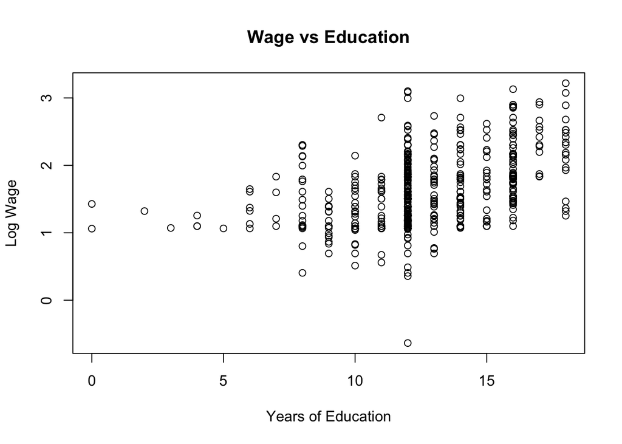

## Statistical Question: Do educated people earn more money?

- Data set of sample of individuals, with education and wages
- Estimation
  - **Regression** summarizes relationship between variables in sample
- Inference
  - **Confidence Interval** for regression coefficient gives range containing population relationship with high probability
  - **Hypothesis Test** indicates whether relationship can be distinguished from a fixed value (say, 0) given sampling variation in data

## Economic Question

- How much would *my* wages change if *I* stayed in school one more year?
- Answer to *statistical* question insufficient to answer this
- What kind of data can be used to answer this question?
- How do we use that data to provide an answer?
- Need an economic model of how data relates to decisions
- Fundamental statistical problems are the same
  - Estimation: how much
  - Inference: how reliable is this estimate
- Answer now depends on our understanding of how observed data relates to causal question of interest
- This affects which estimator we use, how we perform inference
- First part of class, will discuss when and how regression (and variations thereof) can answer these questions

## Statistics

- From your previous classes, you should all be able to
  - Describe the best fitting linear relationship between education and wages
  - Construct confidence intervals for the slope and intercept
  - Visually and numerically assess fit of the relationship

## Ordinary Least Squares Review

Let ${(x_i,y_i):i=1 \ldots n}$ be a sample of measured education levels and log wages from a population of individuals. OLS estimator solves
$$(\hat{\beta_0},\hat{\beta_1})=\arg\min \sum_{i=1}^{n}(y_i-\beta_0-\beta_{1}x_i)^2$$
Giving the formulas
$$\hat{\beta_1}=\frac{\sum_{i=1}^{n}(x_i-\bar{x})(y_i-\bar{y})}{\sum_{i=1}^{n}(x_i-\bar{x})^2}$$
$$\hat{\beta_0}=\bar{y}-\hat{\beta_1}\bar{x}$$

## Regression as statistical model

- You can run OLS on any data set
- Under some assumptions (Wooldrige Ch2), it tells us true features of the population
1. In population, $y=\beta_0+\beta_{1}x+u$
2. ${(x_i,y_i):i=1 \ldots n}$ are independent random sample of observations following 1
3. ${x_i : i=1 \ldots n}$ are not all identical
4. $E(u|x)=0$
5. $Var(u|x)=\sigma^2$ a constant $>0$

## Regression properties

- Under above assumptions, OLS estimator is
1. Consistent: $Pr(|\hat{\beta_1}-\beta_1|>e)\rightarrow 0$ as $n\rightarrow\infty$ for any $e>0$
2. Unbiased: $E(\hat{\beta_1})=\beta_1$
3. Asymptotically normal
   $$Pr(\frac{\sqrt{n}(\hat{\beta_1}-\beta_1)}{\sqrt{\frac{\sigma^2} {\frac{1}{n}\sum_{i=1}^{n}(x_i-\bar{x})^2}}}<t)\rightarrow Pr(Z<t)$$
   for any $t$, where $Z \sim N(0,1)$
- (In practice can replace $\sigma^2$ by $\frac{1}{n-2} \sum (y_i-\hat{\beta_0}-\hat{\beta_{1}}x_i)^2$ )

## Regression Results: Table (Code)

```r
# Obtain access to data sets used in our textbook
library(foreign)
#Load library to make pretty table
suppressWarnings(suppressMessages(library(stargazer)))
# Import data set of education and wages
wage1<-read.dta(
  "http://fmwww.bc.edu/ec-p/data/wooldridge/wage1.dta")
# Regress log wage on years of education
wageregoutput <- lm(formula = lwage ~ educ, data = wage1)
stargazer(wageregoutput,header=FALSE,type="html",
  omit.stat=c("adj.rsq"),font.size="tiny",
  title="Regression of Log Wage on Years of Education")
```

## Regression Results: Table

**Regression of Log Wage on Years of Education**

|  | *Dependent variable:* |
| --- | --- |
|  | lwage |
| educ | 0.083*** |
|  | (0.008) |
| Constant | 0.584*** |
|  | (0.097) |
| Observations | 526 |
| R<sup>2</sup> | 0.186 |
| Residual Std. Error | 0.480 (df = 524) |
| F Statistic | 119.582*** (df = 1; 524) |
| *Note:* | p<0.1; p<0.05; p<0.01 |

## Regression Results: Plot (Code)

```r
# Scatter plot with regression line
plot(wage1$educ,wage1$lwage, xlab = "Years of Education",
      ylab = "Log Wage", main = "Wage vs Education")
abline(wageregoutput,col="red")
```

## Regression Results: Plot

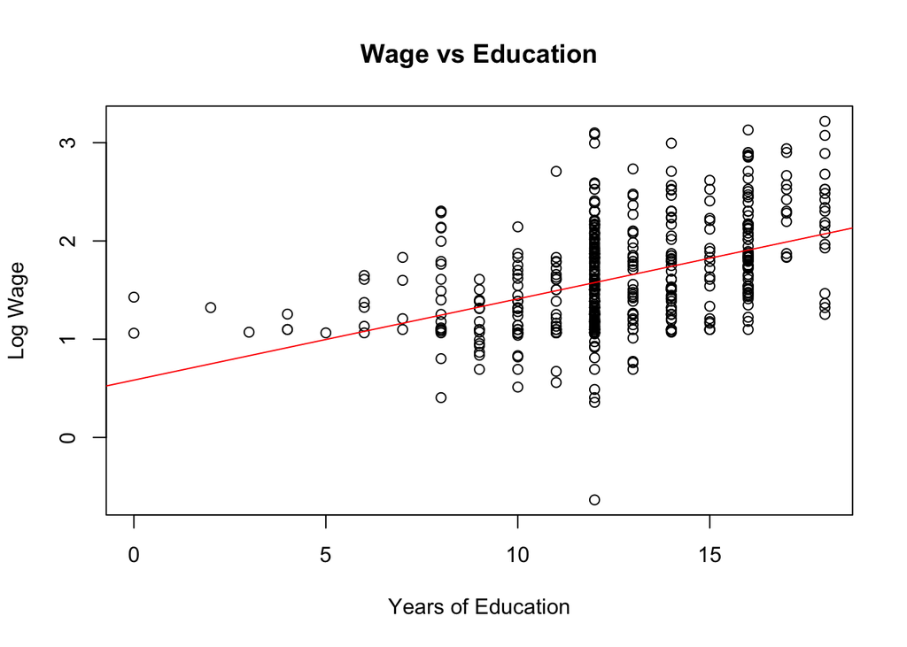

## Note on using R

- Regression results were implemented in **R**
- Command for linear regression

```r
regression<-lm(formula = lwage ~ educ)
summary(regression)
```

- Learn syntax for any command by using **?** in front of name to get help, e.g.

```r
?plot
```

- I will post “Code Display” version of each lecture with R code and explanatory notes for any result displayed in class
- Can also download raw code .Rmd file for each lecture

## Interpretation

- Even when assumptions are satisfied, causal question not answered by above results
- How much would wages change if I stayed in school one more year?
- Maybe education raises wages, or vice versa
  - Or both related to some third factor (job performance?)
- Regression alone won’t tell us this without extra info
- In practice, above assumptions often dubious even as statistical descriptions
- More powerful statistical methods which better describe relationship can help
- Combination of these methods and model of economic situation *together* needed to make headway

## Causal inference strategies

- This course covers research designs which describe situations in which it is possible to extract the causal effect of education on wages
  - Experiments
  - Control
  - Instrumental Variables
  - Fixed Effects
  - Regression Discontinuity
- We will also go over some methods for better *statistical* descriptions of the relationship.

## Nonlinear methods (code)

```r
#Load Libraries for nonparametric estimation
#Install "np" library
install.packages("np",
            repos="http://cran.us.r-project.org")
library(np))
wagebw<-npregbw(ydat=wage1$lwage,xdat=wage1$educ,
    regtype="ll",bws=c(2),
    bandwidth.compute=FALSE, ckertype="uniform")
#Pretty up Names
wagebw$xnames<-"Years of Education"
wagebw$ynames<-"Log Wage"
plot(wagebw,ylim=c(min(wage1$lwage),max(wage1$lwage)),
    main="Wage vs Education, Linear and Nonlinear Fits")
points(wage1$educ,wage1$lwage,pch=1, col="blue")
abline(wageregoutput, col="red")
```

## Nonlinear methods

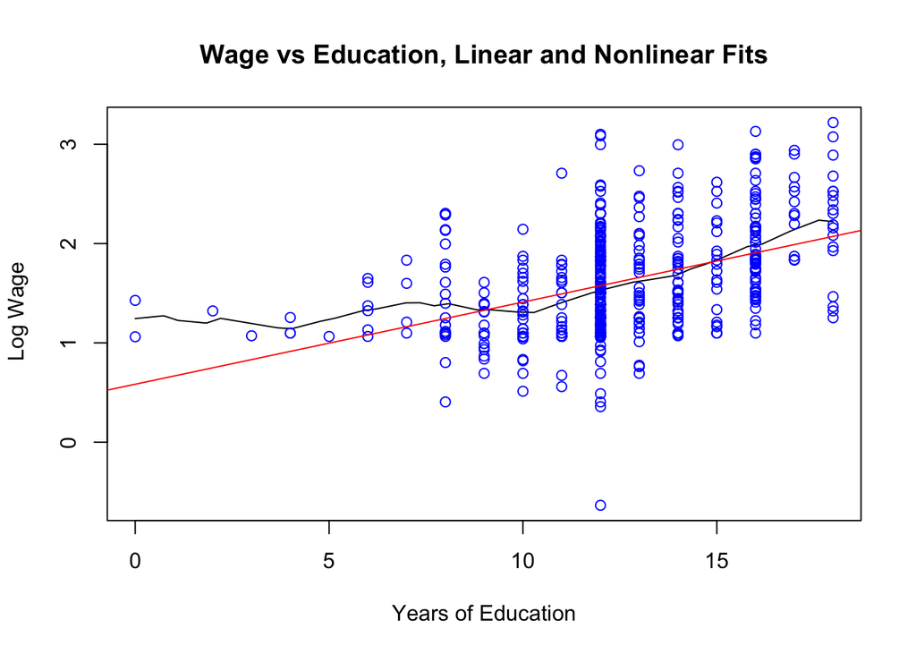

## Assignments and readings

- Readings
  - This week: brush up on linear models/OLS from Econometrics I/Intro to Statistical Inference
  - Wooldridge Appendix B & C Review Probability and Statistics
  - Wooldridge Ch 2-5 review linear regression, univariate and multivariate
- Assignments
  - Problem Set 1